# (Ford GoBike System Data Analysis)

## by (Ahmed Nasr)

## Preliminary Wrangling

> This dataset includes information about individual rides made in a bike-sharing system covering the greater San Francisco Bay area for the month of february,2019. The Dataset was provided by Udacity

### What is the structure of your dataset?

- The original raw dataset contains 183412 observations with 15 features. some variables are numerical and some are categorical. the wrangled dataset contains 174952 observations with 21 features.

### What is/are the main feature(s) of interest in your dataset?

- Age groups of users
- Genders
- Average riding duration

### What features in the dataset do you think will help support your investigation into your feature(s) of interest?

- I beilive the member age, gender, duration of use & user_type are the features of interset.

## Univariate Exploration

### Exploring Group age feature

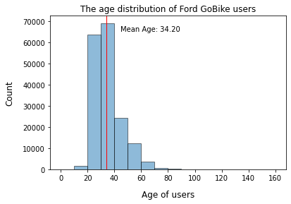

- The mean age for the entire group is 34 years old.

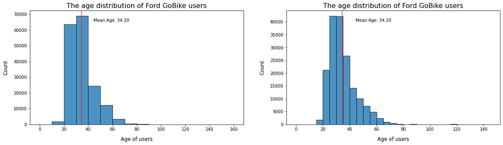

- Outliers can be seen on the right plot.

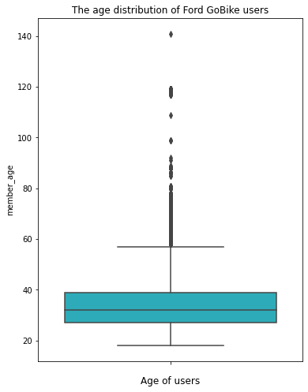

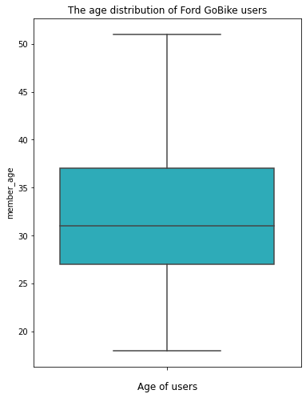

### Exploring User Type feature

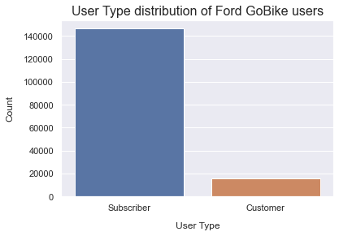

- The majority of bike riders are subscribers.

### Exploring Gender feature

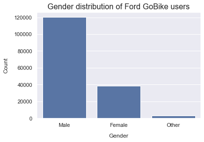

- Male gender is the dominant bike rider.

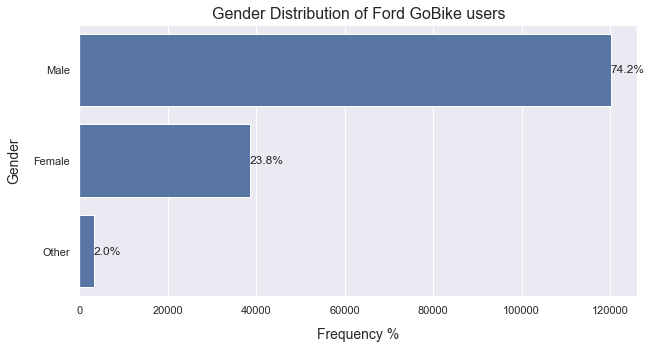

- The percentage of male gender using the bike system is 74.2% , female 23.8%. & other 2%

### Exploring Daily usage feature

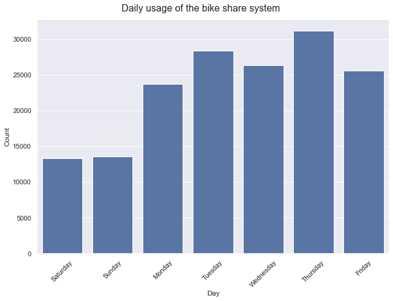

- Higher ride rate on weekdays compared to Weekend.

### Exploring hourly usage feature

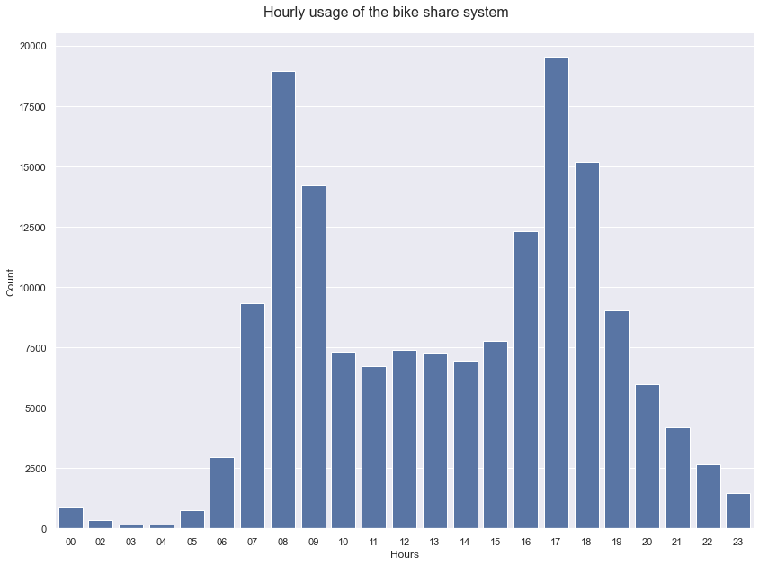

- The heavey use of the systme can be observed during the day is around two periods from 7-9 am & 4-6 pm, that suggests that people use the bike system to compute to work or colleage.

### Exploring Duration feature

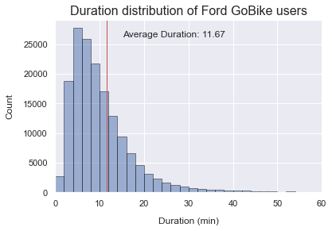

- The average trip duration is 11.67 minutes while the largest duration is around 23 hours (almost one day)

### Discuss the distribution(s) of your variable(s) of interest. Were there any unusual points? Did you need to perform any transformations?

- The member age is right skewed distribution with average age of 34 years but it has unsual points, ages up to 141 years old
- The hourly usage is bi-model distribution with peaks over two periods from 7-9 am & 4-6 pm.
- The duration is right skewed distribution and observed some trip durations up to 23 hours while the avearge trip duration is 11 minutes

### Of the features you investigated, were there any unusual distributions? Did you perform any operations on the data to tidy, adjust, or change the form of the data? If so, why did you do this?

- The member group age have outliers, it was removed from our data to focus of user group age from 18-min to 51-max

## Bivariate Exploration

### Exploring the member age of the different user type

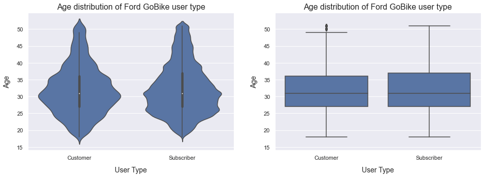

- The overall age distribution of Subscribers shows slightly higher ages compared to customers however, the age range from 25-30 years are less usage of bike system compared to customers.

### Exploring the usage of the bike system member age of the different gender

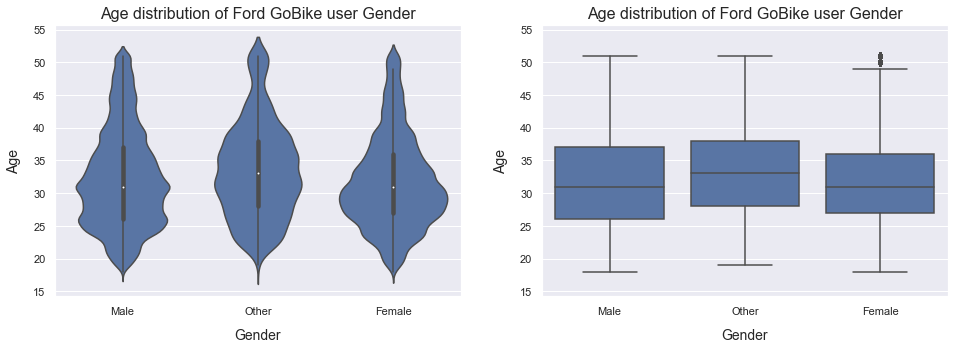

- Now we can notice the range of age from 25-30 in the subscribers who are less using the bike system are mostly male gender.
- Bike system usage by Female Gender in range of 25-30 years are higher compared to male & other gender.
- Bike system usage by 35 years and higher is in favour of male gender.

### Exploring the weekly usage of bike rides with Member_Gender (Male, Female & Other)

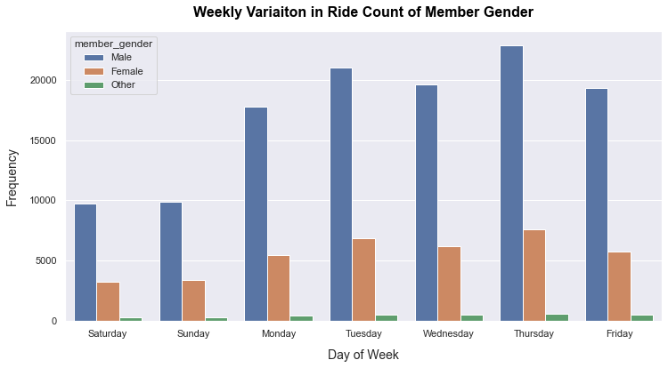

- Overall male gender shows higher usage of bike system in all weekdays and weekends.
- Interstingly the pattern of bike system usage by male & female are pretty similar, i.e. the highest frequency of male ride is on thursday same as female. same pattern for all week.

### Exploring the weekly usage of bike rides with User_type (customers & subscribers)

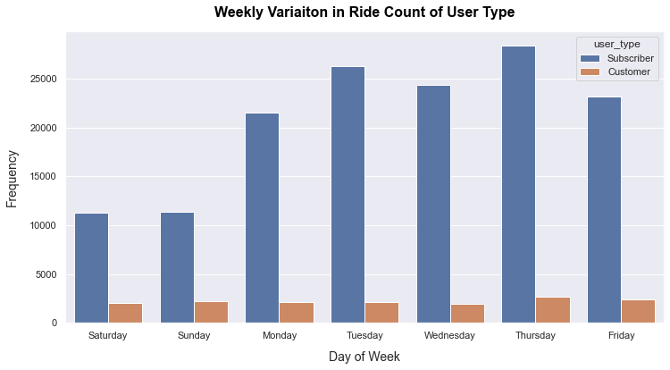

- The bike system usage by customers is pretty flat during the week.
- Subscribers usage of the syatem is higher in all week.

### Exploring the overall usage of bike rides of Gender Member in each User_type (customers & subscribers)

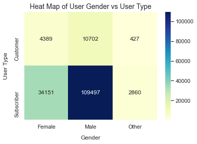

- Overall subscriber users are highly using the bike ride system compared to custmoer users.
- Male subscriber users are highly using the system follwed by female users then other gender.

### Exploring the bike ride duration for each User_type (customers & subscribers)

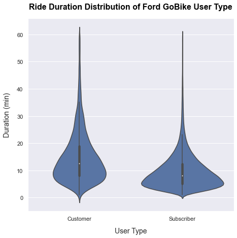

- Customer users have a high travel duration from 20-60 min comapred to subscriber users.
- Subscriber users have a low travel duration less than 10 min compared to customer users. likely they have a fixed schedule which probably explain the lower duration trips.

### Did you observe any interesting relationships between the other features (not the main feature(s) of interest)?

- I found an intersting relationship in the variability of system usage during the week by gender particulary, male & female. the pattern of bike system usage by male & female are pretty similar. i.e. the highest frequency of male ride is on thursday same as female ride. same pattern for all week!

## Multivariate Exploration

### Exploring the trip duration distribution in minutes per user type and gender using violinplot

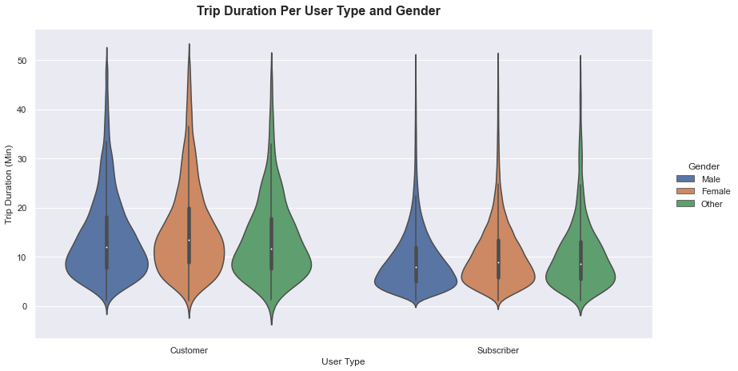

- We can observe that male subscibers are the main influencer in subscribers users in the low travel duration less than 10 min compared to customer users as a conclusion to what we spotted earlier in the preceeding chart.

### Exploring the trip duration distribution in minutes per gender and member age

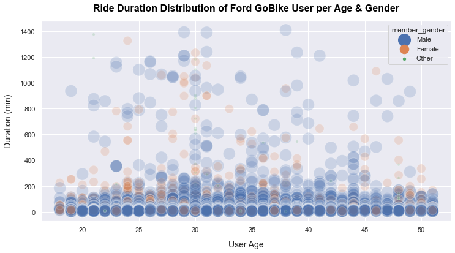

- This plot does not show quit a clear picture, lets seperate all three genders into different plots

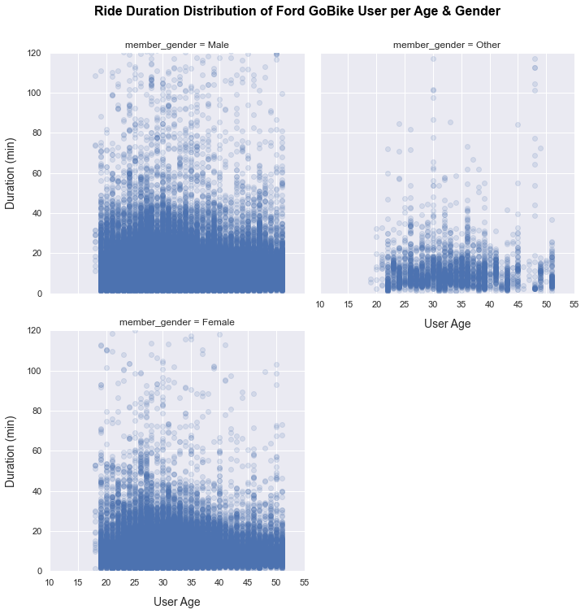

- Here we can see male gender of 35 and older have higher bike ride duration over 30 minutes compared to female of similar age range.

### Talk about some of the relationships you observed in this part of the investigation. Were there features that strengthened each other in terms of looking at your feature(s) of interest?

- Observed that male subscibers are the main influencer in subscribers users in the low travel duration less than 10 min compared to customer users as a explanation to what i spotted ealier in the bivariant chart between user_type & duration.

### Were there any interesting or surprising interactions between features?

- No